# Marker Gene Identification

Nov 2021

## Single Cell RNAseq Analysis Workflow

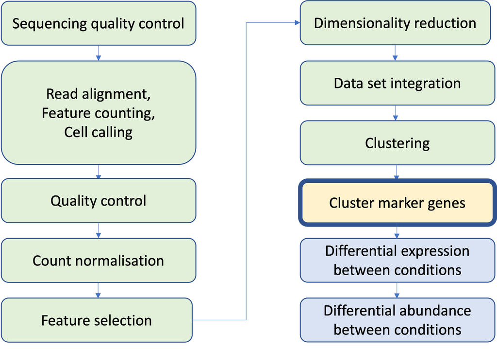

## Identifying Cluster Marker Genes

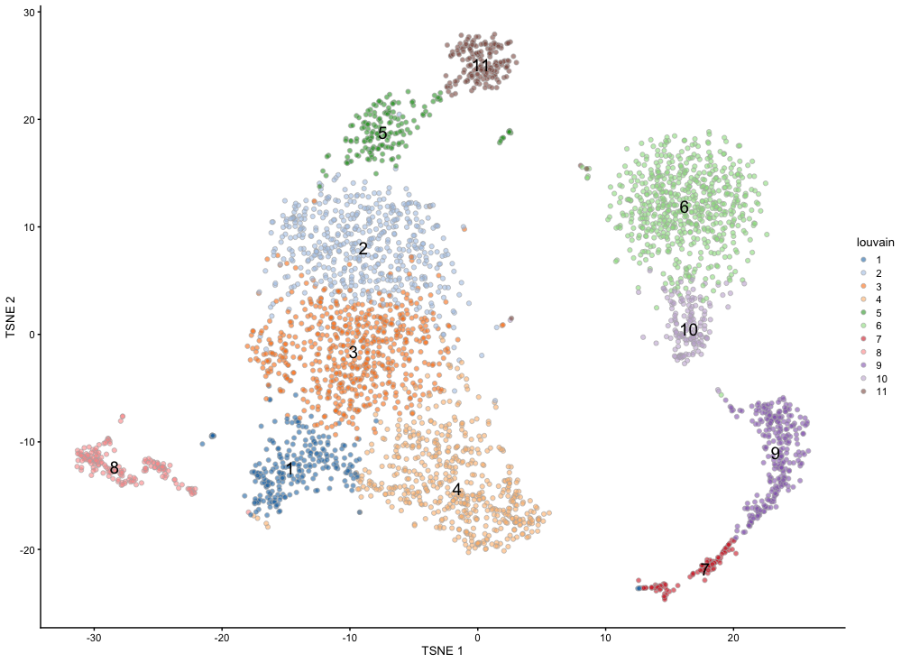

Our goal is to identify genes that are differently expressed between clusters

- exclusively expressed in a single cluster or not
- different methods that test for:
  - differences in the mean expression level
  - differences in the rank of expression
  - differences in the proportion of cells expressing the gene
- compile a summary table

## Differential expression

- Differential expression is comparative. Common comparisons include:
- pairwise cluster comparisons
  - eg. cluster 1 vs cluster2, cluster 1 vs cluster 3, cluster 2 vs cluster 3, etc…
- for a given cluster find ‘marker genes’ that are:
  - DE compared to at least one other cluster
  - DE compared to each of the other clusters
  - DE compared to “most” of the other clusters
  - DE and up-regulated (easier to interpret)
- cell-type comparisons (if cell type is known) - with and without clustering

## `findMarkers`

```r
findMarkers(
  sce,
  groups = sce$louvain,       # clusters to compare
  block = sce$SampleGroup,    # covariates in statistical model
  test.type = "t",            # t-test (default)
  direction = "any",          # test for either higher or lower expression (default)
  lfc = 0,                    # null hypothesis log-fold-change = 0 (default)
  pval.type = "any"           # ranking of p-values based on any comparison (default)
)
```

## `findMarkers`

```r
findMarkers(
  sce,
  groups = sce$louvain,       # clusters to compare
  block = sce$SampleGroup,    # covariates in statistical model
  test.type = "t",            # t-test (default)
  direction = "any",          # test for either higher or lower expression (default)
  lfc = 0,                    # null hypothesis log-fold-change = 0 (default)
  pval.type = "any"           # ranking of p-values based on any comparison (default)
)
```

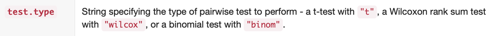

## Gene-wise null hypothesis

- t-test: “Is the mean expression of a gene in cluster 1 and cluster 2 the same?”
- Wilcoxon rank-sum test: “It is equally likely that a randomly selected cell from cluster 1 has higher or lower expression of a gene than a randomly selected cell from cluster 2?”
- Binomial test: “Is the probability of a gene being expressed the same in cluster 1 and cluster 2?”

## Statistical challenges

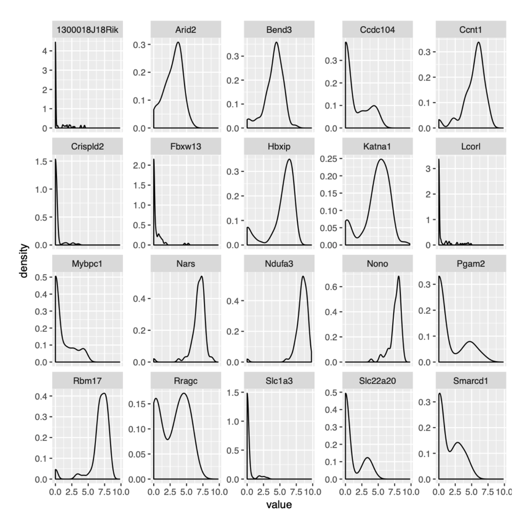

To an extent, all these models poorly capture the underlying features of the data.

- high noise levels (technical and biological factors)
- small library sizes
- small amounts of available mRNAs result in amplification biases and dropout events
- 3’ bias, partial coverage, uneven depth of transcripts
- stochastic nature of transcription
- multimodality in gene expression (presence of multiple possible cell states within a cell population)

## Performance of different tests

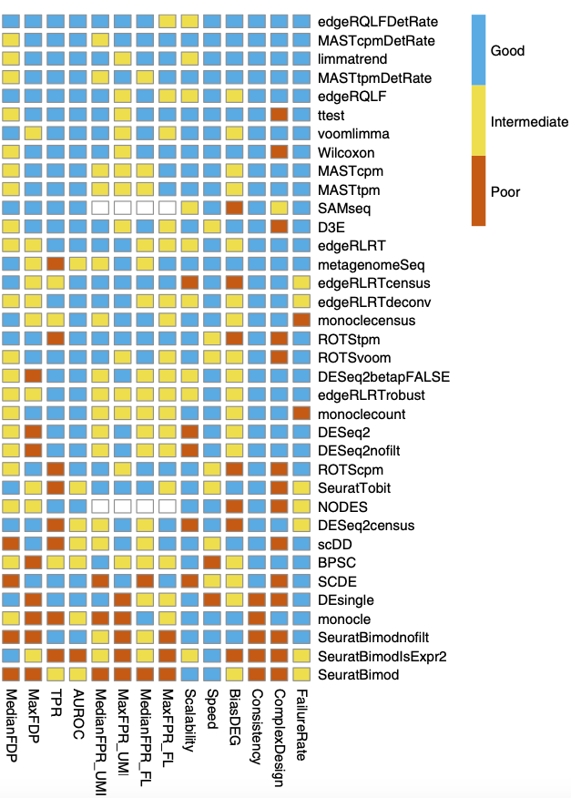

However:

- t-test and Wilcoxon rank-sum test work well in practice, given at least few dozens cells to compare
- Bulk RNA-seq analysis methods do not generally perform worse than those specifically developed for scRNA-seq
- Filtering out lowly expressed genes in quite important for good performance of bulk methods (edgeR, DEseq2)

(source: [Soneson & Robinson 2018](https://doi.org/10.1038/nmeth.4612))

## So, what’s really important?

- understand what are we trying to compare with the different tests (difference in mean expression, difference in probability of being expressed, probability of being highly/lowly expressed)
- It’s important to understand the underlying data
- It’s important to assess and **validate the results**
  - Strictly speaking, identifying genes differentially expressed between clusters is statistically flawed, since the clusters were themselves defined based on the gene expression data itself. Validation is crucial as a follow-up from these analyses.

## Things to think about: during analysis

- Do not use batch-integrated expression data for differential analysis
  - Instead, **include batch in the statistical model** (the `findMarkers()` function has the `block` argument to achieve this)
- Depending on the method you choose use: counts, normalised counts or log-normalized counts.
- Normalization strategy has a big influence on the results in differential expression.
  - e.g comparing cell types with few expressed genes vs a cell type with many genes.

## Things to think about: after analysis

- A lot of what you get might be noise. Take two random set of cells and run DE and you probably with have a few significant genes with most of the commonly used tests.
- Think of the results as hypotheses that need independent verification (e.g. microscopy, qPCR)